# Importing Data

### Data import

In the first part of second day’s training, we will cover

- Importing data of various types
- Importing unstructured data
- Importing Excel data

We will look at how data can be imported into R from different sources and how data with different formats can be handled using R.

Flat files are simple files that display data in tables. csv files are flat files.

utils package in R contain the functionalities for importing csv files into r. We don’t have to import utils package as it is loaded by default.

```r
retail = read.csv("retail.csv", header = TRUE,  sep=",", stringsAsFactors=FALSE)
str(retail)
```

```
## 'data.frame':    20 obs. of  4 variables:
##  $ X1      : int  1 1 1 1 1 1 2 2 2 2 ...
##  $ X121    : int  231 544 213 221 214 322 90 89 78 121 ...
##  $ X200000 : int  450000 800000 400000 389000 478900 750000 65000 66000 54000 95000 ...
##  $ Mirpur.6: chr  "Mirpur 6" "Mirpur 6" "Mirpur 6" "Mirpur 6" ...
```

```r
retail
```

```
##    X1 X121 X200000  Mirpur.6
## 1   1  231  450000  Mirpur 6
## 2   1  544  800000  Mirpur 6
## 3   1  213  400000  Mirpur 6
## 4   1  221  389000  Mirpur 6
## 5   1  214  478900  Mirpur 6
## 6   1  322  750000  Mirpur 6
## 7   2   90   65000 Mirpur 12
## 8   2   89   66000 Mirpur 12
## 9   2   78   54000 Mirpur 12
## 10  2  121   95000 Mirpur 12
## 11  2  132  102000 Mirpur 12
## 12  2  213  378000 Mirpur 12
## 13  2  278  510000 Mirpur 12
## 14  3  789 1650000 Gulshan-1
## 15  3  879 1800000 Gulshan-1
## 16  3  567 1278650 Gulshan-1
## 17  3  432 9900000 Gulshan-1
## 18  3  768 1435658 Gulshan-1
## 19  3  891 1995450 Gulshan-1
## 20  3  743 1742367 Gulshan-1
```

We can also use **read.csv2** function to read **;** separated file

```r
retail = read.csv2("retail.csv", stringsAsFactors=FALSE, sep = ",")
str(retail)
```

```
## 'data.frame':    20 obs. of  4 variables:
##  $ X1      : int  1 1 1 1 1 1 2 2 2 2 ...
##  $ X121    : int  231 544 213 221 214 322 90 89 78 121 ...
##  $ X200000 : int  450000 800000 400000 389000 478900 750000 65000 66000 54000 95000 ...
##  $ Mirpur.6: chr  "Mirpur 6" "Mirpur 6" "Mirpur 6" "Mirpur 6" ...
```

```r
retail
```

```
##    X1 X121 X200000  Mirpur.6
## 1   1  231  450000  Mirpur 6
## 2   1  544  800000  Mirpur 6
## 3   1  213  400000  Mirpur 6
## 4   1  221  389000  Mirpur 6
## 5   1  214  478900  Mirpur 6
## 6   1  322  750000  Mirpur 6
## 7   2   90   65000 Mirpur 12
## 8   2   89   66000 Mirpur 12
## 9   2   78   54000 Mirpur 12
## 10  2  121   95000 Mirpur 12
## 11  2  132  102000 Mirpur 12
## 12  2  213  378000 Mirpur 12
## 13  2  278  510000 Mirpur 12
## 14  3  789 1650000 Gulshan-1
## 15  3  879 1800000 Gulshan-1
## 16  3  567 1278650 Gulshan-1
## 17  3  432 9900000 Gulshan-1
## 18  3  768 1435658 Gulshan-1
## 19  3  891 1995450 Gulshan-1
## 20  3  743 1742367 Gulshan-1
```

For **read.csv()**, by default, header=TRUE and sep=“,”

To have a look at all the files in the directory, use **dir()**

We also come across tab-delimited files. We read these with **read.delim()** function.

```r
values = read.delim("countryValues.txt", stringsAsFactors = FALSE)
str(values)
```

```
## 'data.frame':    12 obs. of  3 variables:
##  $ Year   : int  1920 1930 1940 1950 1960 1970 1980 1990 2000 2010 ...
##  $ Country: chr  "Bangladesh" "Bangladesh" "Bangladesh" "Bangladesh" ...
##  $ Value  : int  2890 3000 4500 2890 3000 8700 1290 15430 9903 13456 ...
```

```r
head(values, 3)
```

```
##   Year    Country Value
## 1 1920 Bangladesh  2890
## 2 1930 Bangladesh  3000
## 3 1940 Bangladesh  4500
```

If the txt file didn’t contain column names, we can specify them by using **col.names=c(“Year”, “Country”, “Value”)** inside **read.delim()** function.

For **read.delim()**, the default is **header = TRUE**, **sep = “”**

Now suppose the values are given with backslash ‘/’ as the separator. We then need to use **read.table()** function.

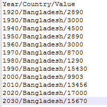

Here we have countryValues2.txt as ‘/’ separated file. Let’s import it.

```r
values2 = read.table("countryValues2.txt", header = TRUE,  sep="/", stringsAsFactors=FALSE)
str(values2)
```

```
## 'data.frame':    12 obs. of  3 variables:
##  $ Year   : int  1920 1930 1940 1950 1960 1970 1980 1990 2000 2010 ...
##  $ Country: chr  "Bangladesh" "Bangladesh" "Bangladesh" "Bangladesh" ...
##  $ Value  : int  2890 3000 4500 2890 3000 8700 1290 15430 9903 13456 ...
```

```r
head(values2, 3)
```

```
##   Year    Country Value
## 1 1920 Bangladesh  2890
## 2 1930 Bangladesh  3000
## 3 1940 Bangladesh  4500
```

We can also use read.table to read tab-delimited file by specifying **sep=“”**

Select the year with highest and highest value

```r
highest = values2[which.max(values2$Value), ]
highest
```

```
##    Year    Country Value
## 11 2020 Bangladesh 17000
```

### Task

#### Select the year with lowest and lowest value?

Now suppose we have the previous tab delimited dataset without any column name and with a new column indicating different states (poor, medium, good, very good) which is categorical in nature. How do we read this data?

Here, we can’t just use stringsAsFactors argument to import both character and categorical columns.

```r
values3 <- read.delim("countryValues3.txt", header = FALSE,
                       col.names = c("Year", "Country", "Value", "State"),
                       colClasses = c("numeric", "character", "numeric", "factor"))
str(values3)
```

```
## 'data.frame':    12 obs. of  4 variables:
##  $ Year   : num  1920 1930 1940 1950 1960 1970 1980 1990 2000 2010 ...
##  $ Country: chr  "Bangladesh" "Bangladesh" "Bangladesh" "Bangladesh" ...
##  $ Value  : num  2890 3000 4500 2890 3000 ...
##  $ State  : Factor w/ 4 levels "Good","Medium",..: 3 3 3 3 3 2 3 1 2 1 ...
```

```r
head(values3, 3)
```

```
##   Year    Country Value State
## 1 1920 Bangladesh  2890  Poor
## 2 1930 Bangladesh  3000  Poor
## 3 1940 Bangladesh  4500  Poor
```

Please note that if a column is set to “NULL” in the **colClasses** vector, this column will not be loaded into the data frame.

### readr and data.table packages

First, load the package

```r
#install.packages("readr")
library(readr)
```

```r
read_csv("retail.csv")
```

```
## # A tibble: 20 x 4
##      `1` `121` `200000` `Mirpur 6`
##    <int> <int>    <int> <chr>
##  1     1   231   450000 Mirpur 6
##  2     1   544   800000 Mirpur 6
##  3     1   213   400000 Mirpur 6
##  4     1   221   389000 Mirpur 6
##  5     1   214   478900 Mirpur 6
##  6     1   322   750000 Mirpur 6
##  7     2    90    65000 Mirpur 12
##  8     2    89    66000 Mirpur 12
##  9     2    78    54000 Mirpur 12
## 10     2   121    95000 Mirpur 12
## 11     2   132   102000 Mirpur 12
## 12     2   213   378000 Mirpur 12
## 13     2   278   510000 Mirpur 12
## 14     3   789  1650000 Gulshan-1
## 15     3   879  1800000 Gulshan-1
## 16     3   567  1278650 Gulshan-1
## 17     3   432  9900000 Gulshan-1
## 18     3   768  1435658 Gulshan-1
## 19     3   891  1995450 Gulshan-1
## 20     3   743  1742367 Gulshan-1
```

#### We use read_tsv for reading tab-separated file

**read_tsv(file_name, col_names=vector of column names)**

#### read.table() vs read.delim()

```r
values2 = read.table("countryValues2.txt", header = TRUE,  sep="/", stringsAsFactors=FALSE)
values2
```

```
##    Year    Country Value
## 1  1920 Bangladesh  2890
## 2  1930 Bangladesh  3000
## 3  1940 Bangladesh  4500
## 4  1950 Bangladesh  2890
## 5  1960 Bangladesh  3000
## 6  1970 Bangladesh  8700
## 7  1980 Bangladesh  1290
## 8  1990 Bangladesh 15430
## 9  2000 Bangladesh  9903
## 10 2010 Bangladesh 13456
## 11 2020 Bangladesh 17000
## 12 2030 Bangladesh 15670
```

#### In read_delim, we don’t have to mention header and stringsAsFactors

```r
values2_delim = read_delim("countryValues2.txt", delim="/")
values2_delim
```

```
## # A tibble: 12 x 3
##     Year Country    Value
##    <int> <chr>      <int>
##  1  1920 Bangladesh  2890
##  2  1930 Bangladesh  3000
##  3  1940 Bangladesh  4500
##  4  1950 Bangladesh  2890
##  5  1960 Bangladesh  3000
##  6  1970 Bangladesh  8700
##  7  1980 Bangladesh  1290
##  8  1990 Bangladesh 15430
##  9  2000 Bangladesh  9903
## 10  2010 Bangladesh 13456
## 11  2020 Bangladesh 17000
## 12  2030 Bangladesh 15670
```

If column name is absent, we need to say **col_names=FALSE** inside **read_delim()**

```r
values3_delim = read_delim("countryValues4.txt", delim="/",col_names=FALSE)
values3_delim
```

```
## # A tibble: 12 x 3
##       X1 X2            X3
##    <int> <chr>      <int>
##  1  1920 Bangladesh  2890
##  2  1930 Bangladesh  3000
##  3  1940 Bangladesh  4500
##  4  1950 Bangladesh  2890
##  5  1960 Bangladesh  3000
##  6  1970 Bangladesh  8700
##  7  1980 Bangladesh  1290
##  8  1990 Bangladesh 15430
##  9  2000 Bangladesh  9903
## 10  2010 Bangladesh 13456
## 11  2020 Bangladesh 17000
## 12  2030 Bangladesh 15670
```

We can specify column names also with **read_delim()s**

```r
values3_delim2 = read_delim("countryValues4.txt", delim="/",
                            col_names=c("Year","Country","Value"))
values3_delim2
```

```
## # A tibble: 12 x 3
##     Year Country    Value
##    <int> <chr>      <int>
##  1  1920 Bangladesh  2890
##  2  1930 Bangladesh  3000
##  3  1940 Bangladesh  4500
##  4  1950 Bangladesh  2890
##  5  1960 Bangladesh  3000
##  6  1970 Bangladesh  8700
##  7  1980 Bangladesh  1290
##  8  1990 Bangladesh 15430
##  9  2000 Bangladesh  9903
## 10  2010 Bangladesh 13456
## 11  2020 Bangladesh 17000
## 12  2030 Bangladesh 15670
```

We can also specify column types using **col_types**

```r
read_delim("countryValues4.txt", delim="/",
                            col_names=c("Year","Country","Value"),
           col_types ="cci")
```

```
## # A tibble: 12 x 3
##    Year  Country    Value
##    <chr> <chr>      <int>
##  1 1920  Bangladesh  2890
##  2 1930  Bangladesh  3000
##  3 1940  Bangladesh  4500
##  4 1950  Bangladesh  2890
##  5 1960  Bangladesh  3000
##  6 1970  Bangladesh  8700
##  7 1980  Bangladesh  1290
##  8 1990  Bangladesh 15430
##  9 2000  Bangladesh  9903
## 10 2010  Bangladesh 13456
## 11 2020  Bangladesh 17000
## 12 2030  Bangladesh 15670
```

```r
read_delim("countryValues5.txt", delim="/",
                            col_names=c("Year","Country","Value"),
           col_types ="cci", skip = 3)
```

```
## # A tibble: 12 x 3
##    Year  Country    Value
##    <chr> <chr>      <int>
##  1 1920  Bangladesh  2890
##  2 1930  Bangladesh  3000
##  3 1940  Bangladesh  4500
##  4 1950  Bangladesh  2890
##  5 1960  Bangladesh  3000
##  6 1970  Bangladesh  8700
##  7 1980  Bangladesh  1290
##  8 1990  Bangladesh 15430
##  9 2000  Bangladesh  9903
## 10 2010  Bangladesh 13456
## 11 2020  Bangladesh 17000
## 12 2030  Bangladesh 15670
```

To skip a column, we can use **_** in **col_types**. To skip rows, we can use **skip =** Use **nmax** to read a specified number of rows.

```r
read_delim("countryValues5.txt", delim="/",
                            col_names=c("Year","Value"),
           col_types ="c_i", skip = 3, n_max=4)
```

```
## # A tibble: 4 x 2
##   Year  Value
##   <chr> <int>
## 1 1920   2890
## 2 1930   3000
## 3 1940   4500
## 4 1950   2890
```

```r
data4=read_tsv("countryValues3.txt",
                            col_names=c("Year","Country","Value","State"),
           col_types ="ccic", skip = 0, n_max=5)
#data4
summary(data4)
```

```
##      Year             Country              Value         State
##  Length:5           Length:5           Min.   :2890   Length:5
##  Class :character   Class :character   1st Qu.:2890   Class :character
##  Mode  :character   Mode  :character   Median :3000   Mode  :character
##                                        Mean   :3256
##                                        3rd Qu.:3000
##                                        Max.   :4500
```

### fread() in data.table() package

```r
library(data.table)
```

We can use fread() to read data both with header and without header in an easier way

```r
fread("retail.csv")
```

```
##     V1  V2      V3        V4
##  1:  1 121  200000  Mirpur 6
##  2:  1 231  450000  Mirpur 6
##  3:  1 544  800000  Mirpur 6
##  4:  1 213  400000  Mirpur 6
##  5:  1 221  389000  Mirpur 6
##  6:  1 214  478900  Mirpur 6
##  7:  1 322  750000  Mirpur 6
##  8:  2  90   65000 Mirpur 12
##  9:  2  89   66000 Mirpur 12
## 10:  2  78   54000 Mirpur 12
## 11:  2 121   95000 Mirpur 12
## 12:  2 132  102000 Mirpur 12
## 13:  2 213  378000 Mirpur 12
## 14:  2 278  510000 Mirpur 12
## 15:  3 789 1650000 Gulshan-1
## 16:  3 879 1800000 Gulshan-1
## 17:  3 567 1278650 Gulshan-1
## 18:  3 432 9900000 Gulshan-1
## 19:  3 768 1435658 Gulshan-1
## 20:  3 891 1995450 Gulshan-1
## 21:  3 743 1742367 Gulshan-1
##     V1  V2      V3        V4
```

```r
fread("retail_without_header.csv")
```

```
##     V1  V2      V3        V4
##  1:  1 121  200000  Mirpur 6
##  2:  1 231  450000  Mirpur 6
##  3:  1 544  800000  Mirpur 6
##  4:  1 213  400000  Mirpur 6
##  5:  1 221  389000  Mirpur 6
##  6:  1 214  478900  Mirpur 6
##  7:  1 322  750000  Mirpur 6
##  8:  2  90   65000 Mirpur 12
##  9:  2  89   66000 Mirpur 12
## 10:  2  78   54000 Mirpur 12
## 11:  2 121   95000 Mirpur 12
## 12:  2 132  102000 Mirpur 12
## 13:  2 213  378000 Mirpur 12
## 14:  2 278  510000 Mirpur 12
## 15:  3 789 1650000 Gulshan-1
## 16:  3 879 1800000 Gulshan-1
## 17:  3 567 1278650 Gulshan-1
## 18:  3 432 9900000 Gulshan-1
## 19:  3 768 1435658 Gulshan-1
## 20:  3 891 1995450 Gulshan-1
## 21:  3 743 1742367 Gulshan-1
##     V1  V2      V3        V4
```

We can also use other formats and **fread()** somehow guesses the separator and column types. We can also manually mention these inside **fread()**.

```r
fread("countryValues.txt")
```

```
##     Year    Country Value
##  1: 1920 Bangladesh  2890
##  2: 1930 Bangladesh  3000
##  3: 1940 Bangladesh  4500
##  4: 1950 Bangladesh  2890
##  5: 1960 Bangladesh  3000
##  6: 1970 Bangladesh  8700
##  7: 1980 Bangladesh  1290
##  8: 1990 Bangladesh 15430
##  9: 2000 Bangladesh  9903
## 10: 2010 Bangladesh 13456
## 11: 2020 Bangladesh 17000
## 12: 2030 Bangladesh 15670
```

We can also select particular columns to import or drop

```r
#Only select first and fourth column
fread("countryValues6.txt", select=c(1,4))
```

```
##     Year     State
##  1: 1920      Poor
##  2: 1930      Poor
##  3: 1940      Poor
##  4: 1950      Poor
##  5: 1960      Poor
##  6: 1970    Medium
##  7: 1980      Poor
##  8: 1990      Good
##  9: 2000    Medium
## 10: 2010      Good
## 11: 2020 Very Good
## 12: 2030      Good
```

#### We can also select by column names

```r
fread("countryValues6.txt", select=c("Year","State"))
```

```
##     Year     State
##  1: 1920      Poor
##  2: 1930      Poor
##  3: 1940      Poor
##  4: 1950      Poor
##  5: 1960      Poor
##  6: 1970    Medium
##  7: 1980      Poor
##  8: 1990      Good
##  9: 2000    Medium
## 10: 2010      Good
## 11: 2020 Very Good
## 12: 2030      Good
```

#### Similarly, we can drop columns by index and column names

```r
fread("countryValues6.txt", drop=c(2,3))
```

```
##     Year     State
##  1: 1920      Poor
##  2: 1930      Poor
##  3: 1940      Poor
##  4: 1950      Poor
##  5: 1960      Poor
##  6: 1970    Medium
##  7: 1980      Poor
##  8: 1990      Good
##  9: 2000    Medium
## 10: 2010      Good
## 11: 2020 Very Good
## 12: 2030      Good
```

```r
fread("countryValues6.txt", drop=c("Country","Value"))
```

```
##     Year     State
##  1: 1920      Poor
##  2: 1930      Poor
##  3: 1940      Poor
##  4: 1950      Poor
##  5: 1960      Poor
##  6: 1970    Medium
##  7: 1980      Poor
##  8: 1990      Good
##  9: 2000    Medium
## 10: 2010      Good
## 11: 2020 Very Good
## 12: 2030      Good
```

#### Reading Microsoft Excel files readxl package

```r
#install.packages("readxl")
library(readxl)
```

#### Name of the sheets in the excel file with excel_sheets()

```r
excel_sheets("retail.xlsx")
```

```
## [1] "retail"          "retail_noHeader" "Sheet1"
```

#### read_excel() is used to read excel file.

**read_excel(filename, sheet = sheetindex or sheetname)**. Note that, if we don’t specify sheet here, then the first sheet will be read in.

##### Without providing sheet argument

```r
read_excel("retail.xlsx")
```

```
## # A tibble: 21 x 4
##    `Store No` `Items Sold` Revenue Location
##         <dbl>        <dbl>   <dbl> <chr>
##  1          1          121  200000 Mirpur 6
##  2          1          231  450000 Mirpur 6
##  3          1          544  800000 Mirpur 6
##  4          1          213  400000 Mirpur 6
##  5          1          221  389000 Mirpur 6
##  6          1          214  478900 Mirpur 6
##  7          1          322  750000 Mirpur 6
##  8          2           90   65000 Mirpur 12
##  9          2           89   66000 Mirpur 12
## 10          2           78   54000 Mirpur 12
## # ... with 11 more rows
```

#### Reading with sheet index

```r
read_excel("retail.xlsx", sheet=2)
```

```
## # A tibble: 20 x 4
##      `1` `121` `200000` `Mirpur 6`
##    <dbl> <dbl>    <dbl> <chr>
##  1     1   231   450000 Mirpur 6
##  2     1   544   800000 Mirpur 6
##  3     1   213   400000 Mirpur 6
##  4     1   221   389000 Mirpur 6
##  5     1   214   478900 Mirpur 6
##  6     1   322   750000 Mirpur 6
##  7     2    90    65000 Mirpur 12
##  8     2    89    66000 Mirpur 12
##  9     2    78    54000 Mirpur 12
## 10     2   121    95000 Mirpur 12
## 11     2   132   102000 Mirpur 12
## 12     2   213   378000 Mirpur 12
## 13     2   278   510000 Mirpur 12
## 14     3   789  1650000 Gulshan-1
## 15     3   879  1800000 Gulshan-1
## 16     3   567  1278650 Gulshan-1
## 17     3   432  9900000 Gulshan-1
## 18     3   768  1435658 Gulshan-1
## 19     3   891  1995450 Gulshan-1
## 20     3   743  1742367 Gulshan-1
```

#### Reading with sheet name

```r
read_excel("retail.xlsx", sheet="retail_noHeader")
```

```
## # A tibble: 20 x 4
##      `1` `121` `200000` `Mirpur 6`
##    <dbl> <dbl>    <dbl> <chr>
##  1     1   231   450000 Mirpur 6
##  2     1   544   800000 Mirpur 6
##  3     1   213   400000 Mirpur 6
##  4     1   221   389000 Mirpur 6
##  5     1   214   478900 Mirpur 6
##  6     1   322   750000 Mirpur 6
##  7     2    90    65000 Mirpur 12
##  8     2    89    66000 Mirpur 12
##  9     2    78    54000 Mirpur 12
## 10     2   121    95000 Mirpur 12
## 11     2   132   102000 Mirpur 12
## 12     2   213   378000 Mirpur 12
## 13     2   278   510000 Mirpur 12
## 14     3   789  1650000 Gulshan-1
## 15     3   879  1800000 Gulshan-1
## 16     3   567  1278650 Gulshan-1
## 17     3   432  9900000 Gulshan-1
## 18     3   768  1435658 Gulshan-1
## 19     3   891  1995450 Gulshan-1
## 20     3   743  1742367 Gulshan-1
```

#### Reading all sheets with a single command

```r
#We will get the data of 3 sheets as three lists each containing the respective dataset
all_sheets = lapply(excel_sheets("retail.xlsx"), read_excel, path="retail.xlsx")
str(all_sheets)
```

```
## List of 3
##  $ :Classes 'tbl_df', 'tbl' and 'data.frame':    21 obs. of  4 variables:
##   ..$ Store No  : num [1:21] 1 1 1 1 1 1 1 2 2 2 ...
##   ..$ Items Sold: num [1:21] 121 231 544 213 221 214 322 90 89 78 ...
##   ..$ Revenue   : num [1:21] 200000 450000 800000 400000 389000 ...
##   ..$ Location  : chr [1:21] "Mirpur 6" "Mirpur 6" "Mirpur 6" "Mirpur 6" ...
##  $ :Classes 'tbl_df', 'tbl' and 'data.frame':    20 obs. of  4 variables:
##   ..$ 1       : num [1:20] 1 1 1 1 1 1 2 2 2 2 ...
##   ..$ 121     : num [1:20] 231 544 213 221 214 322 90 89 78 121 ...
##   ..$ 200000  : num [1:20] 450000 800000 400000 389000 478900 ...
##   ..$ Mirpur 6: chr [1:20] "Mirpur 6" "Mirpur 6" "Mirpur 6" "Mirpur 6" ...
##  $ :Classes 'tbl_df', 'tbl' and 'data.frame':    6 obs. of  3 variables:
##   ..$ conty    : chr [1:6] "Bangladesh" "Bangladesh" "India" "India" ...
##   ..$ year     : num [1:6] 2018 2010 2018 2010 2018 ...
##   ..$ sex Ratio: num [1:6] 102 104 105 109 101 ...
```

```r
all_sheets
```

```
## [[1]]
## # A tibble: 21 x 4
##    `Store No` `Items Sold` Revenue Location
##         <dbl>        <dbl>   <dbl> <chr>
##  1          1          121  200000 Mirpur 6
##  2          1          231  450000 Mirpur 6
##  3          1          544  800000 Mirpur 6
##  4          1          213  400000 Mirpur 6
##  5          1          221  389000 Mirpur 6
##  6          1          214  478900 Mirpur 6
##  7          1          322  750000 Mirpur 6
##  8          2           90   65000 Mirpur 12
##  9          2           89   66000 Mirpur 12
## 10          2           78   54000 Mirpur 12
## # ... with 11 more rows
```

[output cut: 36 more lines]

Let’s explore its documentation. Remember, how?

**col_names**, **col_types** and **skip** are some other useful arguments.

```r
#Note that blank in col_types skip the respective column
read_excel("retail.xlsx", sheet=3, col_types = c("text","numeric","numeric"),
           skip = 1, col_names = c("country", "year", "sex-ratio"))
```

```
## # A tibble: 6 x 3
##   country     year `sex-ratio`
##   <chr>      <dbl>       <dbl>
## 1 Bangladesh  2018        102.
## 2 Bangladesh  2010        104.
## 3 India       2018        105.
## 4 India       2010        109.
## 5 China       2018        101.
## 6 China       2010        104.
```

We can also specify the range of values that we want to import using **range** inside **read_excel()**.

```r
read_excel(path="retail.xlsx", range="A1:D11", sheet="retail")
```

```
## # A tibble: 10 x 4
##    `Store No` `Items Sold` Revenue Location
##         <dbl>        <dbl>   <dbl> <chr>
##  1          1          121  200000 Mirpur 6
##  2          1          231  450000 Mirpur 6
##  3          1          544  800000 Mirpur 6
##  4          1          213  400000 Mirpur 6
##  5          1          221  389000 Mirpur 6
##  6          1          214  478900 Mirpur 6
##  7          1          322  750000 Mirpur 6
##  8          2           90   65000 Mirpur 12
##  9          2           89   66000 Mirpur 12
## 10          2           78   54000 Mirpur 12
```

We can also mention the highest number of rows to be read using **n_max**.

```r
read_excel(path="retail.xlsx", range="A1:D11", sheet="retail", n_max =10)
```

```
## # A tibble: 10 x 4
##    `Store No` `Items Sold` Revenue Location
##         <dbl>        <dbl>   <dbl> <chr>
##  1          1          121  200000 Mirpur 6
##  2          1          231  450000 Mirpur 6
##  3          1          544  800000 Mirpur 6
##  4          1          213  400000 Mirpur 6
##  5          1          221  389000 Mirpur 6
##  6          1          214  478900 Mirpur 6
##  7          1          322  750000 Mirpur 6
##  8          2           90   65000 Mirpur 12
##  9          2           89   66000 Mirpur 12
## 10          2           78   54000 Mirpur 12
```

We can also mention the range of rows or range of columns separately using **cell_rows()** and **cell_col()** respectively.

```r
read_excel(path="retail.xlsx", sheet="retail", range = cell_rows(3:6))
```

```
## # A tibble: 3 x 4
##     `1` `231` `450000` `Mirpur 6`
##   <dbl> <dbl>    <dbl> <chr>
## 1     1   544   800000 Mirpur 6
## 2     1   213   400000 Mirpur 6
## 3     1   221   389000 Mirpur 6
```

Is this what we were expecting??

No, let’s fix it.

```r
#read_excel(path="retail.xlsx", range = cell_rows(3:6))
```

We can also mention the sheetname inside **range**.

```r
#read_excel("retail.xlsx", range = "Economy!B1:C4")
```

We can also use **read.xls()** from gdata package. All the arguments of **read.table()** is available for **read.xls()** function. This package first converts an Excel file to a csv file using Perl. This is time consuming for a large excel file.

```r
#install.packages("gdata")
library(gdata)
#read.xls("retail.xls", sheet="retail")
```

### XLConnect package

This is useful if most of our files we work in are in Excel file. We can adapt our calculation sheet to R using this package.

```r
#install.packages("XLConnect")
#library(XLConnect)
```

We read sheets using **loadWorkbook()**.

```r
#excel = loadWorkbook("retail.xlsx")
#class(excel)
```

Now let’s have a look at all the sheets using **getSheets()**

```r
#getSheets(excel)
```

#### Reading data with **readWorksheet()** function

```r
#readWorksheet(excel, sheet = "retail.xlsx")
#This is similar to read_excel
```

We can specify starting and ending row and also starting and ending column.

```r
# readWorksheet(excel, sheet = "retail", startRow=4,
#               endRow = 10, startCol = 3, endCol = 10,
#               header = FALSE)
```

We can create new worksheet and save it in excel working from R.

```r
# tech = data.frame(Country = c("Bangladesh", "China", "India", "USA", "Irreland"),
#                                                 Internet = c(34,56,45,76,71))
# excel = loadWorkbook("retail.xlsx")
# #Create a new sheet in excel file
# createSheet(excel, name = "Tech")
# #Populate the new worksheet with the value of dataframe tech
# writeWorksheet(excel, tech, sheet = "Tech")
# saveWorkbook(excel, file = "airStations_mod.xlsx")
```

We can also rename sheets using **renameSheet()** function.

```r
# renameSheet(excel, "retail", "retail2")
# saveWorkbook(excel, file = "data.xlsx")
```

We can also remove sheet using **removeSheet()**.

```r
# removeSheet(excel, sheet = "retail")
# saveWorkbook(excel, file = "retail2.xlsx")
```